# P1

Violencia de género

2 junio 2023

# **Tema**

**Percepción de los estudiantes de la Universidad de Ingeniería y Tecnología (UTEC), que cursan el ciclo 2023-1, ante la violencia de género en el Perú**

# **Introducción**

## **Relevancia**

El tema del informe ayuda a comprender la magnitud del problema: Conocer la percepción de los estudiantes sobre la violencia de género puede ayudar a comprender la magnitud del problema en el país y en las universidades en particular. La percepción de los estudiantes sobre la violencia de género puede ayudar a identificar áreas de mejora en la prevención y respuesta a la violencia de género en las universidades.

## **Objetivos**

- Identificar el grado de conciencia de los estudiantes de UTEC sobre la prevalencia y los efectos de la violencia de género en el Perú
- Identificar los factores subyacentes que contribuyen a la perpetuación de la violencia de género en la sociedad peruana según la percepción de los estudiantes de la UTEC.
- Evaluar la percepción de los estudiantes de la UTEC sobre las medidas y políticas actuales para prevenir y abordar la violencia de género en la UTEC y en el Perú

## **Contexto**

El término “violencia de género” hace referencia a cualquier acto con el que se busque dañar a una persona por su género. La violencia de género nace de normas perjudiciales, abuso de poder y desigualdades de género.

# **Datos**

## **Proceso de recolección de datos:**

En este trabajo, los datos fueron obtenidos mediante una encuesta en google forms.Esta encuesta contaba con preguntas relacionadas a las variables directamente, y otras que dan contexto a los encuestados.

## **Población,muestra y muestreo:**

- **Población:** Estudiantes de UTEC que estudien en el ciclo 2023-1 mayores de 17 años.
- **Muestra:** 151 estudiantes que completaron el formulario
- **Muestreo:** Se trata de un muestreo por conveniencia, porque nos dedicamos a parar estudiantes para que puedan rellenar el formulario

## **Variables**

[output not shown]

## **Limpieza de base de datos**

```r
tablita <-'respuestas1.csv'
Data <- read.csv(tablita)
```

Mediante el comando **summary**, podemos ver que las variables fueron leidas correctamente.

```r
summary(Data)
```

```
##  Marca.temporal     Ingrese.su.genero       Edad
##  Length:151         Length:151         Min.   :17.00
##  Class :character   Class :character   1st Qu.:18.00
##  Mode  :character   Mode  :character   Median :19.00
##                                        Mean   :19.22
##                                        3rd Qu.:20.00
##                                        Max.   :24.00
##  Â.A.que.carrera.perteneces. Â.En.que.escala.de.pensiÃ³n.te.encuentras.
##  Length:151                  Length:151
##  Class :character            Class :character
##  Mode  :character            Mode  :character
##
##
##
##  Â.CuÃ.ntas.horas.dedicas.al.estudio.AL.DIA.
##  Min.   :1.000
##  1st Qu.:2.250
##  Median :3.500
##  Mean   :3.854
##  3rd Qu.:5.000
##  Max.   :9.000
##  Â.QuÃ..clase.de.violencia.de.gÃ.nero.cree.que.es.mÃ.s.frecuente.â..
##  Length:151
##  Class :character
##  Mode  :character
##
##
##
##  X..Desde.su.punto.de.vista..Â.existe.la.violencia.de.gÃ.nero..
##  Length:151
##  Class :character
##  Mode  :character
##
##
##
##  X..Â.Ha.recibido.algÃºn.tipo.de.charla.informativa.en.la.universidad.sobre.la.violencia.de.gÃ.nero..
##  Length:151
##  Class :character
##  Mode  :character
##
```

[output cut: 211 more lines]

```
##
##  X..Â.Ha.presenciado.actos.sexistas.en.la.universidad..      X
##  Length:151                                             Length:151
##  Class :character                                       Class :character
##  Mode  :character                                       Mode  :character
##
##
##
##      X.1                X.2
##  Length:151         Length:151
##  Class :character   Class :character
##  Mode  :character   Mode  :character
##
##
##
```

```r
Data <- Data[, -43]
Data <- Data[, -42]
Data <- Data[, -41]
Data <- Data[, -1]
```

Hacemos uso del comando **colnames** para poder reemplazar el nombre de las variables.

```r
nombr.columnas <-c("Género","Edad","Carrera","EscalaPension","HorasEstudio","ViolenciaGenero","ExisteViolenciaG","CharlaInformativa","VictimaViolenciaG","HogarViolencia","CercanosViolenciaG","ProblemaEnPeru","ParticipaCampaña","EducacionPreviene","CasosViolencia","CasosProcesados","ConoceViolenciaG","MedidasPrevencion","EstadoEfectivo","LugarMasFrecuente","InstruidoViolenciaG","OrigenViolenciaG","AcudirPorAyuda","InfluenciaDeMedios","ProblemaSoloMujeres","DenunciasDeVictimas","DenunciasViolenciaMujer","ViolenciaAMujeres","RazonAgresionMujeres","CampañaNiUnaMenos","ViolenciaAHombes","TipoViolenciaHombre","RazonViolenciaHombre","LibertadMujer","HombreMayorAccesoEducacion","DiferenciaSalarial","HombreMayorAscensoLaboral","AccesoCargoPolitico","ActosSexistasEnUniversidad")


colnames(Data)<-nombr.columnas
head(Data)
```

```
##      Género Edad                Carrera EscalaPension HorasEstudio
## 1 Masculino   23  IngenierÃa MecÃ¡nica             E          2.0
## 2 Masculino   18  IngenierÃa MecÃ¡nica             D          5.5
## 3  Femenino   20  IngenierÃa Ambiental             E          4.0
## 4 Masculino   19 IngenierÃa Industrial             E          4.5
## 5 Masculino   18  IngenierÃa MecÃ¡nica             C          4.5
## 6  Femenino   18 IngenierÃa Industrial             E          5.5
##          ViolenciaGenero ExisteViolenciaG CharlaInformativa VictimaViolenciaG
## 1 Violencia PsicolÃ³gica               Si                Si                No
## 2 Violencia PsicolÃ³gica               Si                Si                No
## 3 Violencia PsicolÃ³gica               Si                Si                Si
## 4       Violencia Sexual               Si                Si                No
## 5 Violencia PsicolÃ³gica               Si                Si                No
## 6       Violencia Sexual               Si                Si                No
##   HogarViolencia CercanosViolenciaG ProblemaEnPeru ParticipaCampaña
```

[output cut: 90 more lines]

Para poder ver cuántas filas(número de observaciones)

```r
nrow(Data)
```

```
## [1] 151
```

Para ver cúantas columnas(número de variables)

```r
ncol(Data)
```

```
## [1] 39
```

```r
Data$InfluenciaDeMedios[Data$InfluenciaDeMedios == "Negativamente"]<-"Negativo"
Data$InfluenciaDeMedios[Data$InfluenciaDeMedios == "Positivamente"]<-"Positivo"
Data$InfluenciaDeMedios[Data$InfluenciaDeMedios == "No influyen"]<-"Nulo"

Data$ConoceViolenciaG[Data$ConoceViolenciaG == 1]<-"Muy poco informado"
Data$ConoceViolenciaG[Data$ConoceViolenciaG == 2]<-"Poco informado"
Data$ConoceViolenciaG[Data$ConoceViolenciaG == 3]<-"Algo informado"
Data$ConoceViolenciaG[Data$ConoceViolenciaG == 4]<-"Informado"
Data$ConoceViolenciaG[Data$ConoceViolenciaG == 5]<-"Muy informado"

Data$MedidasPrevencion[Data$MedidasPrevencion == 1]<-"Muy malas"
Data$MedidasPrevencion[Data$MedidasPrevencion == 2]<-"Malas"
Data$MedidasPrevencion[Data$MedidasPrevencion == 3]<-"Regulares"
Data$MedidasPrevencion[Data$MedidasPrevencion == 4]<-"Buenas"
Data$MedidasPrevencion[Data$MedidasPrevencion == 5]<-"Muy buenas"

Data$EstadoEfectivo[Data$EstadoEfectivo == 1]<-"No efectivo"
Data$EstadoEfectivo[Data$EstadoEfectivo == 2]<-"Poco efectivo"
Data$EstadoEfectivo[Data$EstadoEfectivo == 3]<-"Regularmente efectivo"
Data$EstadoEfectivo[Data$EstadoEfectivo == 4]<-"Efectivo"
Data$EstadoEfectivo[Data$EstadoEfectivo == 5]<-"Muy efectivo"

Data$ViolenciaGenero[Data$ViolenciaGenero == "Violencia Física"]<-"Fisica"
Data$ViolenciaGenero[Data$ViolenciaGenero == "Violencia Psicológica"]<-"Psicologica"
Data$ViolenciaGenero[Data$ViolenciaGenero == "Violencia Emocional"]<-"Emocional"
Data$ViolenciaGenero[Data$ViolenciaGenero == "Violencia Sexual"]<-"Sexual"
Data$ViolenciaGenero[Data$ViolenciaGenero == "Violencia Económica"]<-"Economica"
Data$ViolenciaGenero[Data$ViolenciaGenero == "Violencia Institucional"]<-"Institucional"
Data$ViolenciaGenero[Data$ViolenciaGenero == "Violencia No existe violencia de género"]<-"No existe"

head(Data[c(17,18,19,24)])
```

```
##   ConoceViolenciaG MedidasPrevencion EstadoEfectivo InfluenciaDeMedios
## 1   Algo informado             Malas  Poco efectivo           Negativo
## 2        Informado             Malas  Poco efectivo           Negativo
## 3    Muy informado             Malas  Poco efectivo           Negativo
## 4        Informado            Buenas  Poco efectivo               Nulo
## 5    Muy informado             Malas  Poco efectivo               Nulo
## 6    Muy informado             Malas  Poco efectivo           Negativo
```

Para hacer más fácil la limpieza de datos usamos en el google forms opciones multiples.Y ahorrarnos problemas de typeo en diferentes preguntas.

```r
# Verificar si hay datos nulos en el dataframe
nulos <- colSums(is.na(Data))

# Mostrar el resultado
print(nulos)
```

```
##                     Género                       Edad
##                          0                          0
##                    Carrera              EscalaPension
##                          0                          0
##               HorasEstudio            ViolenciaGenero
##                          0                          0
##           ExisteViolenciaG          CharlaInformativa
##                          0                          0
##          VictimaViolenciaG             HogarViolencia
##                          0                          0
##         CercanosViolenciaG             ProblemaEnPeru
##                          0                          0
##           ParticipaCampaña          EducacionPreviene
##                          0                          0
##             CasosViolencia            CasosProcesados
##                          0                          0
##           ConoceViolenciaG          MedidasPrevencion
##                          0                          0
##             EstadoEfectivo          LugarMasFrecuente
##                          0                          0
##        InstruidoViolenciaG           OrigenViolenciaG
##                          0                          0
##             AcudirPorAyuda         InfluenciaDeMedios
##                          0                          0
##        ProblemaSoloMujeres        DenunciasDeVictimas
##                          0                          0
##    DenunciasViolenciaMujer          ViolenciaAMujeres
##                          0                          0
##       RazonAgresionMujeres          CampañaNiUnaMenos
##                          0                          0
##           ViolenciaAHombes        TipoViolenciaHombre
##                          0                          0
##       RazonViolenciaHombre              LibertadMujer
##                          0                          0
## HombreMayorAccesoEducacion         DiferenciaSalarial
##                          0                          0
##  HombreMayorAscensoLaboral        AccesoCargoPolitico
##                          0                          0
## ActosSexistasEnUniversidad
##                          0
```

Despúes de todo esto podemos decir que la base de datos está limpia, no hubo datos faltantes registrados por lo que la base de datos no cambio de tamaño en ningún momento

# **Análisis descriptivo**

```r
# Análisis de variables numéricas
# Variables: "Edad" y "Cantidad de horas que estudias al día"
# Para calcular la moda usamos la siguiente función:
mode <- function(x) {
   return(as.numeric(names(which.max(table(x)))))}

# Medidas de resumen
edad_mean <- round(mean(Data$Edad),digits=2)
edad_median <- round(median(Data$Edad),digits=2)
edad_sd <- round(sd(Data$Edad),digits=2)
edad_moda <- mode(Data$Edad)
cat("Para la variable Edad\n - Media:",edad_mean,"\n - Mediana:", edad_median,"\n - Desviación estándar:",edad_sd, "\n - Moda:", edad_moda)
```

```
## Para la variable Edad
##  - Media: 19.22
##  - Mediana: 19
##  - Desviación estándar: 1.64
##  - Moda: 18
```

```r
horas_mean <- round(mean(Data$HorasEstudio),digits=2)
horas_median <- round(median(Data$HorasEstudio),digits=2)
horas_sd <- round(sd(Data$HorasEstudio),digits=2)
cat("\nPara la variable Horas\n - Media:",horas_mean,"\n - Mediana:", horas_median,"\n - Desviación estándar:",horas_sd)
```

```
##
## Para la variable Horas
##  - Media: 3.85
##  - Mediana: 3.5
##  - Desviación estándar: 1.95
```

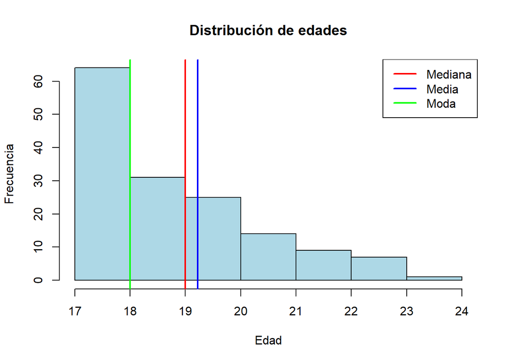

```r
# Gráficos
hist(Data$Edad, col="lightblue", main = "Distribución de edades", xlab = "Edad", ylab = "Frecuencia")
abline(v = edad_mean, col = "blue", lwd = 2)
abline(v = edad_median, col = "red", lwd = 2)
abline(v = edad_moda, col = "green", lwd = 2)
legend("topright", legend = c("Mediana","Media","Moda"), lwd = 2, col = c("red","blue","green"))
```

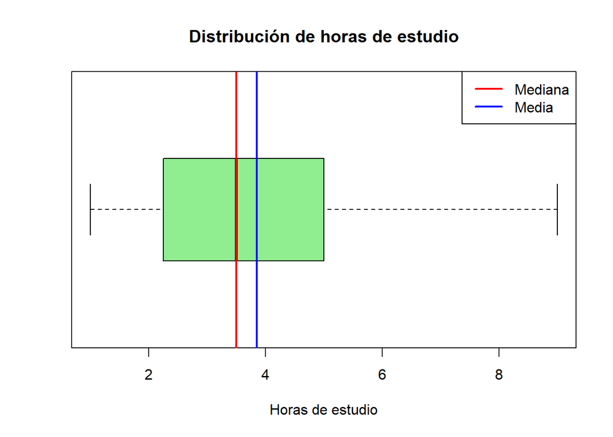

```r
boxplot(Data$HorasEstudio, col="lightgreen", main = "Distribución de horas de estudio", xlab = "Horas de estudio",horizontal=TRUE)
abline(v = horas_mean, col = "blue", lwd = 2)
abline(v = horas_median, col = "red", lwd = 2)
legend("topright", legend = c("Mediana","Media"), lwd = 2, col = c("red","blue"))
```

En cuanto a las variables numéricas, se encontró que la edad promedio de los estudiantes es de 19.22 años, con una mediana de 19 años y una desviación estándar de 1.64 años. En relación a las horas de estudio al día, se observó una distribución con una media de 3.85 horas, una mediana de 3.5 horas y una desviación estándar de 1.95 horas. Estos resultados proporcionan información sobre las características demográficas y los hábitos de estudio de los estudiantes de la UTEC. Observamos como en mayor número tenemos la participación de alumnos entre 17 y 18 años.

```r
# Análisis de variables categóricas

# Tablas de frecuencia
table_cree_violencia <- table(Data$ExisteViolenciaG)
table_charla <- table(Data$CharlaInformativa)
table_vio_hogar <- table(Data$HogarViolencia)
table_ha_sido_victima <- table(Data$VictimaViolenciaG)
table_vio_cerca <- table(Data$CercanosViolenciaG)
table_prob_peru <- table(Data$ProblemaEnPeru)
table_participa <- table(Data$ParticipaCampaña)
table_prevenir_edu <- table(Data$EducacionPreviene)
table_misma_libertad <- table(Data$LibertadMujer)
table_mayor_hedu <- table(Data$HombreMayorAccesoEducacion)
table_dif_sal <- table(Data$DiferenciaSalarial)
table_ascenso <- table(Data$HombreMayorAscensoLaboral)
table_cargo <- table(Data$AccesoCargoPolitico)
table_sex_uni <- table(Data$ActosSexistasEnUniversidad)

# Gráficos de barras
par(mfrow=c(2,2))
barplot(sort(table_cree_violencia,decreasing = TRUE), col="lightblue", main = "Percepción sobre la existencia\nde violencia de género", cex.main = 1, xlab = "Respuesta", ylab = "Frecuencia", ylim=c(0,160))

ExisteViolencia <- table_cree_violencia
porcentajes <- round(prop.table(ExisteViolencia) * 100, 2)
tabla_final <- cbind(ExisteViolencia, porcentajes)
tabla_final
```

```
##    ExisteViolencia porcentajes
## No               8         5.3
## Si             143        94.7
```

```r
barplot(sort(table_ha_sido_victima,decreasing = TRUE), col="lightblue", main = "Experiencia como víctima\nde violencia de género", cex.main = 1, xlab = "Respuesta", ylab = "Frecuencia",ylim=c(0,100))

VictimaViolenciaG <- table_ha_sido_victima
porcentajes <- round(prop.table(VictimaViolenciaG) * 100, 2)
tabla_final <- cbind(VictimaViolenciaG, porcentajes)
tabla_final
```

```
##    VictimaViolenciaG porcentajes
## No                93       61.59
## Si                58       38.41
```

```r
barplot(sort(table_vio_hogar,decreasing = TRUE), col="lightblue", main = "Reflejo de violencia de género\nen el hogar", cex.main = 1, xlab = "Respuesta", ylab = "Frecuencia", ylim=c(0,120))

ViolenciaHogar <- table_vio_hogar
porcentajes <- round(prop.table(ViolenciaHogar) * 100, 2)
tabla_final <- cbind(ViolenciaHogar, porcentajes)
tabla_final
```

```
##    ViolenciaHogar porcentajes
## No            111       73.51
## Si             40       26.49
```

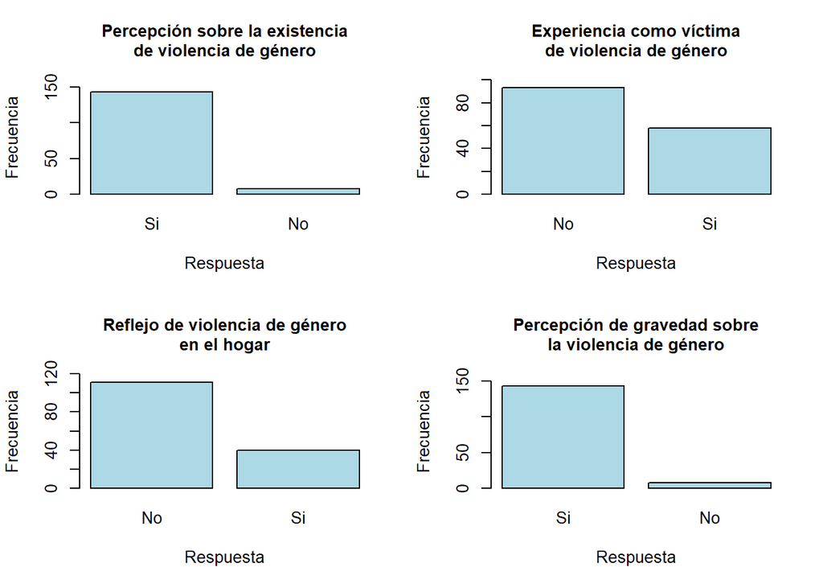

```r
barplot(sort(table_prob_peru,decreasing = TRUE), col="lightblue", main = "Percepción de gravedad sobre\nla violencia de género", cex.main = 1, xlab = "Respuesta", ylab = "Frecuencia", ylim=c(0,160))
```

```r
ProblemaGrave <- table_prob_peru
porcentajes <- round(prop.table(ProblemaGrave) * 100, 2)
tabla_final <- cbind(ProblemaGrave, porcentajes)
tabla_final
```

```
##    ProblemaGrave porcentajes
## No             8         5.3
## Si           143        94.7
```

```r
par(mfrow=c(2,3))
barplot(sort(table_misma_libertad,decreasing = TRUE), col="lightblue", main = "Percepción sobre la menor libertad\nde elección de las mujeres", cex.main = 1, xlab = "Respuesta", ylab = "Frecuencia",ylim=c(0,120))

MismaLibertad <- table_misma_libertad
porcentajes <- round(prop.table(MismaLibertad) * 100, 2)
tabla_final <- cbind(MismaLibertad, porcentajes)
tabla_final
```

```
##    MismaLibertad porcentajes
## No            49       32.45
## Si           102       67.55
```

```r
barplot(sort(table_mayor_hedu,decreasing = TRUE), col="lightblue", main = "Creencia sobre el mayor acceso\na la educación en los hombres", xlab = "Respuesta", cex.main=1, ylab = "Frecuencia",ylim=c(0,100))

MayorAccesoEducacion <- table_mayor_hedu
porcentajes <- round(prop.table(MayorAccesoEducacion) * 100, 2)
tabla_final <- cbind(MayorAccesoEducacion, porcentajes)
tabla_final
```

```
##    MayorAccesoEducacion porcentajes
## No                   66       43.71
## Si                   85       56.29
```

```r
barplot(sort(table_dif_sal,decreasing = TRUE), col="lightblue", main = "Percepción sobre la diferencia salarial\nentre géneros", cex.main = 1, xlab = "Respuesta", ylab = "Frecuencia", ylim=c(0,120))

DiferenciaSalarial <- table_dif_sal
porcentajes <- round(prop.table(DiferenciaSalarial) * 100, 2)
tabla_final <- cbind(DiferenciaSalarial, porcentajes)
tabla_final
```

```
##    DiferenciaSalarial porcentajes
## No                 41       27.15
## Si                110       72.85
```

```r
barplot(sort(table_ascenso,decreasing = TRUE), col="lightblue", main = "Creencia en la mayor posibilidad de\nascenso laboral en hombres", xlab = "Respuesta", cex.main=1, ylab = "Frecuencia", ylim=c(0,120))

AscensoLaboral <- table_ascenso
porcentajes <- round(prop.table(AscensoLaboral) * 100, 2)
tabla_final <- cbind(AscensoLaboral, porcentajes)
tabla_final
```

```
##    AscensoLaboral porcentajes
## No             43       28.48
## Si            108       71.52
```

```r
barplot(sort(table_cargo,decreasing = TRUE), col="lightblue", main = "Creencia en la mayor posibilidad masculina\na acceder a un cargo politico", cex.main = 1, xlab = "Respuesta", ylab = "Frecuencia",ylim=c(0,100))

CargoPolitico <- table_cargo
porcentajes <- round(prop.table(CargoPolitico) * 100, 2)
tabla_final <- cbind(CargoPolitico, porcentajes)
tabla_final
```

```
##    CargoPolitico porcentajes
## No            90        59.6
## Si            61        40.4
```

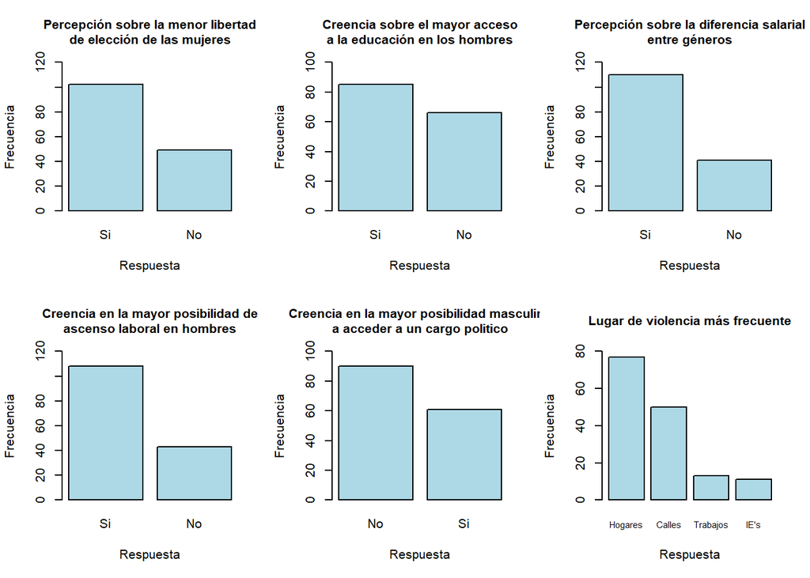

```r
Data$LugarMasFrecuente[Data$LugarMasFrecuente=="Instituciones educativas (colegios, universidades, institutos, etc.)"] <- "IE's"
barplot(sort(table(Data$LugarMasFrecuente),decreasing = TRUE), col="lightblue", main="Lugar de violencia más frecuente", xlab = "Respuesta", cex.main=1, ylab = "Frecuencia", ylim=c(0,80), cex.names = 0.7)
```

```r
LugarFrecuente <- table(Data$LugarMasFrecuente)
porcentajes <- round(prop.table(LugarFrecuente) * 100, 2)
tabla_final <- cbind(LugarFrecuente, porcentajes)
tabla_final
```

```
##          LugarFrecuente porcentajes
## Calles               50       33.11
## Hogares              77       50.99
## IE's                 11        7.28
## Trabajos             13        8.61
```

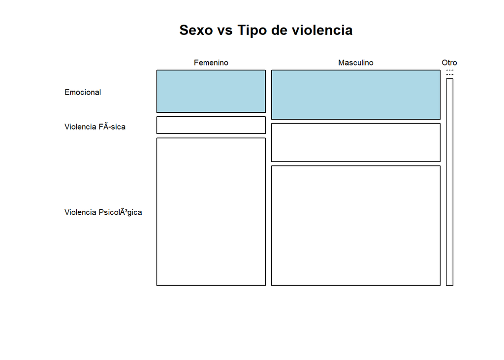

```r
TSO<-table(Data$Género,Data$ViolenciaGenero)
TSO_filtrado <- TSO[, colSums(TSO) > 15]
Colores<-{}
Colores["Emocional"]<-"lightblue"
Colores["Fisica"]<-"lightgreen"
Colores["Psicologica"]<-"lightyellow"
mosaicplot(TSO_filtrado, col = Colores[dimnames(TSO_filtrado)[[2]]],
           main = "Sexo vs Tipo de violencia", las = 1)
```

```r
TipoViolencia <- table(Data$ViolenciaGenero)
porcentajes <- round(prop.table(TipoViolencia) * 100, 2)
tabla_final <- cbind(TipoViolencia, porcentajes)
tabla_final
```

```
##                                TipoViolencia porcentajes
## Emocional                                 28       18.54
## Institucional                              4        2.65
## No existe violencia de gÃ©nero             1        0.66
## Sexual                                    14        9.27
## Violencia EconÃ³mica                       4        2.65
## Violencia FÃsica                         18       11.92
## Violencia PsicolÃ³gica                    82       54.30
```

Objetivo 1: Identificar el grado de conciencia de los estudiantes de UTEC sobre la prevalencia y los efectos de la violencia de género en el Perú:

A partir de los análisis realizados, se observa que para un 94.7% de los estudiantes de la Universidad de Ingeniería y Tecnología (UTEC) son conscientes que la violencia de género existe, y el 54.30% de estudiantes dice que el tipo de violencia más frecuente es la violencia psicológica, y el 94.7% opina que es un problema grave en el Perú, sin haber sido victimas (61.59%) o que se haya reflejado en sus hogares la violencia de género(73.51%). Además entre las consecuencias que desencadena la violencia de género, el 72.85% estuvo de acuedo que las consecuencias más comunes son la diferencia salarial entre los géneros y que los hombres tienen mayor posibilidad de tener un ascenso laboral que una mujer (71.52%).

Así mismo el 50.99% señala a los hogares como el lugar más frecuente en donde ocurrirían actos de violencia de género.

```r
#Cambio de nombres
Data$RazonAgresionMujeres[Data$RazonAgresionMujeres == "Creencias machistas"] <- "Creencias\nmachistas"
Data$RazonAgresionMujeres[Data$RazonAgresionMujeres == "Problemas con el alcohol y las drogas"] <- "Probl de alcohol\ny drogas"
Data$RazonAgresionMujeres[Data$RazonAgresionMujeres == "Problemas psicológicos/mentales"] <- "Probl psicológicos\n/mentales"
Data$RazonAgresionMujeres[Data$RazonAgresionMujeres == "Sufrieron malos tratos cuando eran niños"] <- "Malos tratos\nde niños"
Data$RazonAgresionMujeres[Data$RazonAgresionMujeres == "La violencia aprendida como método de resolución de conflictos"] <- "Violencia aprendida\ncomo solución"
Data$RazonAgresionMujeres[Data$RazonAgresionMujeres == "Por una situación de descontrol"] <- "Descontrol"
Data$RazonAgresionMujeres[Data$RazonAgresionMujeres == "Por los pocos recursos económicos"] <- "Economía\nbaja"
Data$RazonAgresionMujeres[Data$RazonAgresionMujeres == "No son violentadas"] <- "No son\nviolentadas"
Data$RazonAgresionMujeres[Data$RazonAgresionMujeres == "Por la conducta de la mujer"] <- "Conducta de\nla mujer"

Data$RazonViolenciaHombre[Data$RazonViolenciaHombre == "Problemas con el alcohol y las drogas"] <- "Alcohol\ny drogas"
Data$RazonViolenciaHombre[Data$RazonViolenciaHombre == "Problemas psicológicos/mentales"] <- "P. psicológicos\n/mentales"
Data$RazonViolenciaHombre[Data$RazonViolenciaHombre == "Creencias feministas"] <- "Creencias\nfeministas"
Data$RazonViolenciaHombre[Data$RazonViolenciaHombre == "Padres maltratadores"] <- "Maltrato\npadres"
Data$RazonViolenciaHombre[Data$RazonViolenciaHombre == "La violencia aprendida como método de resolución de conflictos"] <- "Violencia\ncomo sol"
Data$RazonViolenciaHombre[Data$RazonViolenciaHombre == "Por la conducta del hombre"] <- "Conducta del\nhombre"
Data$ViolenciaAHombes[Data$ViolenciaAHombes=="No son violentados"] <- "No\nviolencia"
Data$RazonViolenciaHombre[Data$RazonViolenciaHombre == "Por una situación de descontrol"] <- "Descontrol"
Data$RazonViolenciaHombre[Data$RazonViolenciaHombre == "Por los pocos recursos económicos"] <- "Economía\nbaja"
```

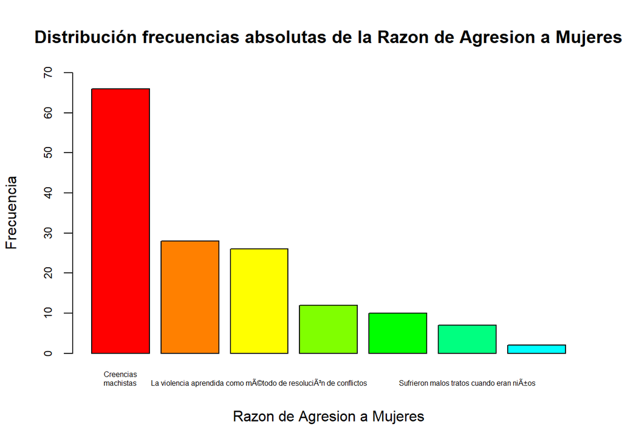

```r
barp <- barplot(sort(table(Data$RazonAgresionMujeres),decreasing = TRUE),
        ylab="Frecuencia",
        xlab="Razon de Agresion a Mujeres",
        main="Distribución frecuencias absolutas de la Razon de Agresion a Mujeres",
        col=rainbow(12), cex.axis = 0.75, cex.names = 0.5, ylim = c(0,70),
        border = "gray1")
```

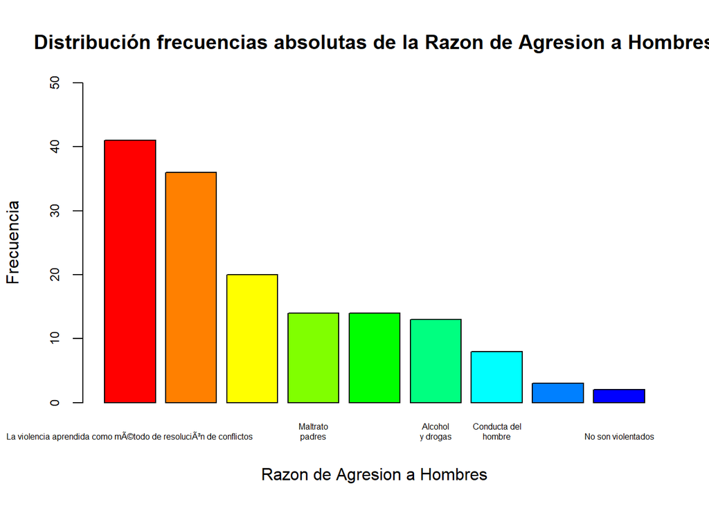

```r
barp <- barplot(sort(table(Data$RazonViolenciaHombre), decreasing = TRUE),
        ylab="Frecuencia",
        xlab="Razon de Agresion a Hombres",
        main="Distribución frecuencias absolutas de la Razon de Agresion a Hombres",
        col=rainbow(12), cex.axis = 0.75, cex.names = 0.5, ylim = c(0,50),
        border = "gray1")
```

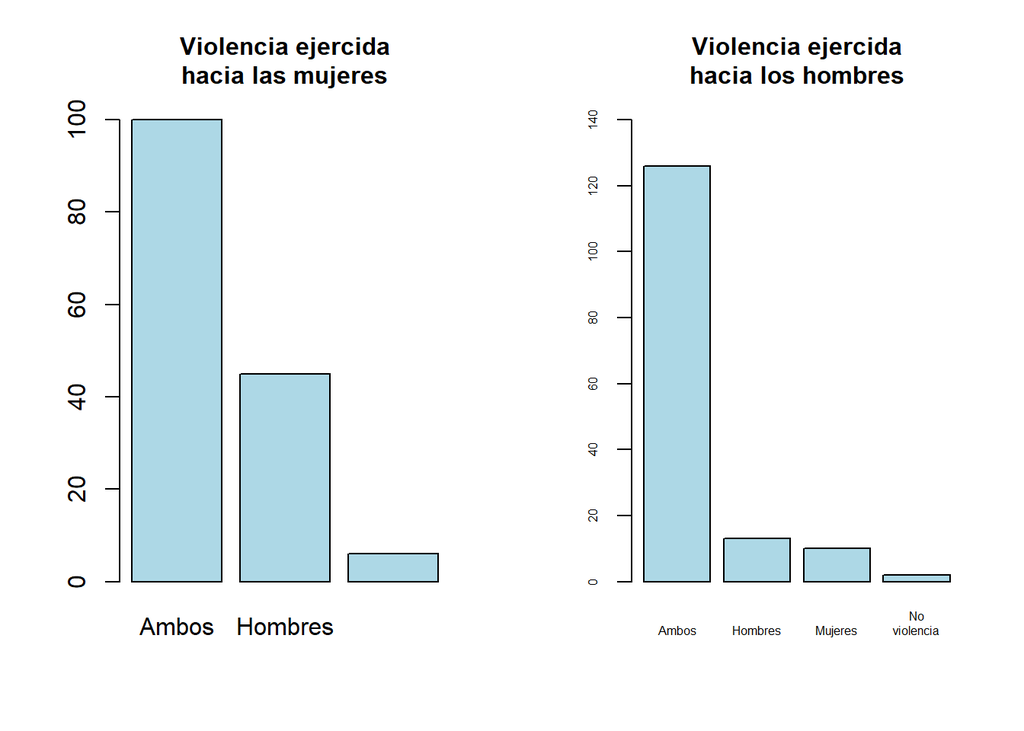

```r
par(mfrow=c(1,2))
barplot(table(Data$ViolenciaAMujeres), ylim=c(0,100), col="lightblue", main="Violencia ejercida\nhacia las mujeres", cex.main=1)


barplot(table(Data$ViolenciaAHombes), ylim=c(0,140), col="lightblue", main="Violencia ejercida\nhacia los hombres", cex.axis=0.5, cex.names = 0.5, cex.main=1)
```

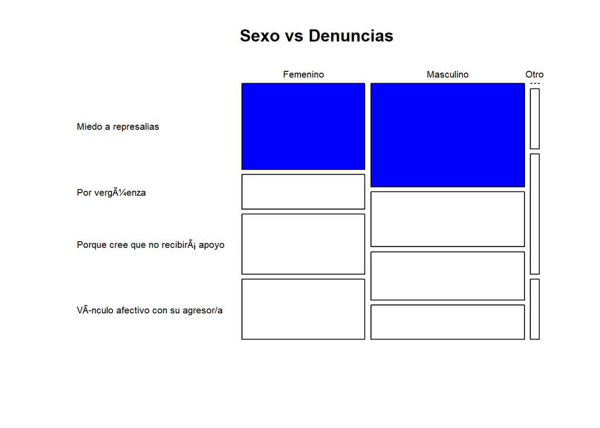

```r
TSO<-table(Data$Género,Data$DenunciasDeVictimas)
TSO_filtrado <- TSO[, colSums(TSO) > 15]
Colores<-{}
Colores["Miedo a represalias"]<-"blue"
Colores["Por vergüenza"]<-"purple"
Colores["Porque cree que no recibirá apoyo"]<-"green"
Colores["Vínculo afectivo con su agresor/a"]<-"red"
mosaicplot(TSO_filtrado, col = Colores[dimnames(TSO_filtrado)[[2]]],
           main = "Sexo vs Denuncias", las = 1)
```

```r
RazonMujeres <- table(Data$RazonAgresionMujeres)
porcentajes <- round(prop.table(RazonMujeres) * 100, 2)
tabla_final <- cbind(RazonMujeres, porcentajes)
tabla_final
```

```
##                                                                  RazonMujeres
## Creencias\nmachistas                                                       66
## La violencia aprendida como mÃ©todo de resoluciÃ³n de conflictos           26
## Por los pocos recursos econÃ³micos                                          2
## Por una situaciÃ³n de descontrol                                           10
## Probl de alcohol\ny drogas                                                 12
## Problemas psicolÃ³gicos/mentales                                           28
## Sufrieron malos tratos cuando eran niÃ±os                                   7
##                                                                  porcentajes
## Creencias\nmachistas                                                   43.71
## La violencia aprendida como mÃ©todo de resoluciÃ³n de conflictos       17.22
## Por los pocos recursos econÃ³micos                                      1.32
## Por una situaciÃ³n de descontrol                                        6.62
## Probl de alcohol\ny drogas                                              7.95
## Problemas psicolÃ³gicos/mentales                                       18.54
## Sufrieron malos tratos cuando eran niÃ±os                               4.64
```

```r
RazonHombres <- table(Data$RazonViolenciaHombre)
porcentajes <- round(prop.table(RazonHombres) * 100, 2)
tabla_final <- cbind(RazonHombres, porcentajes)
tabla_final
```

```
##                                                                  RazonHombres
## Alcohol\ny drogas                                                          13
## Conducta del\nhombre                                                        8
## Creencias\nfeministas                                                      20
## La violencia aprendida como mÃ©todo de resoluciÃ³n de conflictos           41
## Maltrato\npadres                                                           14
## No son violentados                                                          2
## Por los pocos recursos econÃ³micos                                          3
## Por una situaciÃ³n de descontrol                                           14
## Problemas psicolÃ³gicos/mentales                                           36
##                                                                  porcentajes
## Alcohol\ny drogas                                                       8.61
## Conducta del\nhombre                                                    5.30
## Creencias\nfeministas                                                  13.25
## La violencia aprendida como mÃ©todo de resoluciÃ³n de conflictos       27.15
## Maltrato\npadres                                                        9.27
## No son violentados                                                      1.32
## Por los pocos recursos econÃ³micos                                      1.99
## Por una situaciÃ³n de descontrol                                        9.27
## Problemas psicolÃ³gicos/mentales                                       23.84
```

```r
QuienMujeres <- table(Data$ViolenciaAMujeres)
porcentajes <- round(prop.table(QuienMujeres) * 100, 2)
tabla_final <- cbind(QuienMujeres, porcentajes)
tabla_final
```

```
##         QuienMujeres porcentajes
## Ambos            100       66.23
## Hombres           45       29.80
## Mujeres            6        3.97
```

```r
QuienHombres <- table(Data$ViolenciaAHombes)
porcentajes <- round(prop.table(QuienHombres) * 100, 2)
tabla_final <- cbind(QuienHombres, porcentajes)
tabla_final
```

```
##               QuienHombres porcentajes
## Ambos                  126       83.44
## Hombres                 13        8.61
## Mujeres                 10        6.62
## No\nviolencia            2        1.32
```

```r
DenunciaVictimas <- table(Data$DenunciasDeVictimas)
porcentajes <- round(prop.table(DenunciaVictimas) * 100, 2)
tabla_final <- cbind(DenunciaVictimas, porcentajes)
tabla_final
```

```
##                                    DenunciaVictimas porcentajes
## Miedo a represalias                              50       33.11
## No sabe que sufre violencia                       5        3.31
## Para proteger a su familia                       13        8.61
## Por dependencia econÃ³mica                        3        1.99
## Por vergÃ¼enza                                   25       16.56
## Porque cree que no recibirÃ¡ apoyo               30       19.87
## VÃnculo afectivo con su agresor/a               25       16.56
```

```r
EducacionPreviene <- table(Data$EducacionPreviene)
porcentajes <- round(prop.table(EducacionPreviene) * 100, 2)
tabla_final <- cbind(EducacionPreviene, porcentajes)
tabla_final
```

```
##    EducacionPreviene porcentajes
## No                 6        3.97
## Si               145       96.03
```

Objetivo 2: Identificar los factores subyacentes que contribuyen a la perpetuación de la violencia de género en la sociedad peruana según la percepción de los estudiantes de la UTEC.